# Data analysis project: Relatioship of family’s height

Zhuoyue Wang, Weizhuo Wang, Juhee Chung

August 5, 2017

# STAT 420 Data analysis project: The relationship between the height of parents and kids

We usually assume that if both parents are tall, the children would also be tall. But is the fact like what we expected?

In this project, we want to find out whether this cognition is true, and if it is true, how strong is the effect of parents??? height on their children? If there is a relationship between them, what kind of relationship do they have, linear or logarithmic?

Galton’s family heights data has been a preeminent historical dataset in regression analysis, on which the original model and basic results have survived the close scrutiny of statisticians for 132 years. The dataset gives information based on the famous 1885 study of Francis Galton exploring the relationship between the heights of adult children and the heights of their parents. (retrieved from http://www.math.uah.edu/stat/data/Galton.csv ).

The variable information is given below:

Family: The family that the child belongs to, labeled by the numbers from 1 to 204 and 136A

Father: The father’s height, in inches

Mother: The mother’s height, in inches

Average: The average height between father and mother in a family, in inches

Gender: The gender of the child, male (M) or female (F)

Height: The height of the child, in inches

Kids: The number of kids in the family of the child

```r
galton = read.csv("Galton.csv")
summary(galton)
```

```
##      Family        Father          Mother      Gender      Height
##  185    : 15   Min.   :62.00   Min.   :58.00   F:433   Min.   :56.00
##  166    : 11   1st Qu.:68.00   1st Qu.:63.00   M:465   1st Qu.:64.00
##  66     : 11   Median :69.00   Median :64.00           Median :66.50
##  130    : 10   Mean   :69.23   Mean   :64.08           Mean   :66.76
##  136    : 10   3rd Qu.:71.00   3rd Qu.:65.50           3rd Qu.:69.70
##  140    : 10   Max.   :78.50   Max.   :70.50           Max.   :79.00
##  (Other):831
##       Kids           Average
##  Min.   : 1.000   Min.   :62.00
##  1st Qu.: 4.000   1st Qu.:65.50
##  Median : 6.000   Median :66.80
##  Mean   : 6.136   Mean   :66.67
##  3rd Qu.: 8.000   3rd Qu.:67.50
##  Max.   :15.000   Max.   :72.80
##
```

## Simple Linear Regression

```r
ParentAverageVsKid = lm(Height ~ Average, data = galton)
summary(ParentAverageVsKid)
```

```
##
## Call:
## lm(formula = Height ~ Average, data = galton)
##
## Residuals:
##     Min      1Q  Median      3Q     Max
## -8.9710 -2.6807 -0.1771  2.7789 11.6873
##
## Coefficients:
##             Estimate Std. Error t value Pr(>|t|)
## (Intercept) 22.15174    4.30266   5.148 3.23e-07 ***
## Average      0.66905    0.06451  10.371  < 2e-16 ***
## ---
## Signif. codes:  0 '***' 0.001 '**' 0.01 '*' 0.05 '.' 0.1 ' ' 1
##
## Residual standard error: 3.387 on 896 degrees of freedom
## Multiple R-squared:  0.1072, Adjusted R-squared:  0.1062
## F-statistic: 107.6 on 1 and 896 DF,  p-value: < 2.2e-16
```

```r
anova(ParentAverageVsKid)
```

```
## Analysis of Variance Table
##
## Response: Height
##            Df  Sum Sq Mean Sq F value    Pr(>F)
## Average     1  1234.2 1234.22  107.56 < 2.2e-16 ***
## Residuals 896 10280.8   11.47
## ---
## Signif. codes:  0 '***' 0.001 '**' 0.01 '*' 0.05 '.' 0.1 ' ' 1
```

```r
ParentAverageVsKidRMSE = sqrt(mean(resid(ParentAverageVsKid)^2))
ParentAverageVsKidRMSE
```

```
## [1] 3.383579
```

We can see that the p-value is nearly equal to zero. So we can have statistical confidence to conclude that there is a linear relationship between parent’s average height and childen’s height.

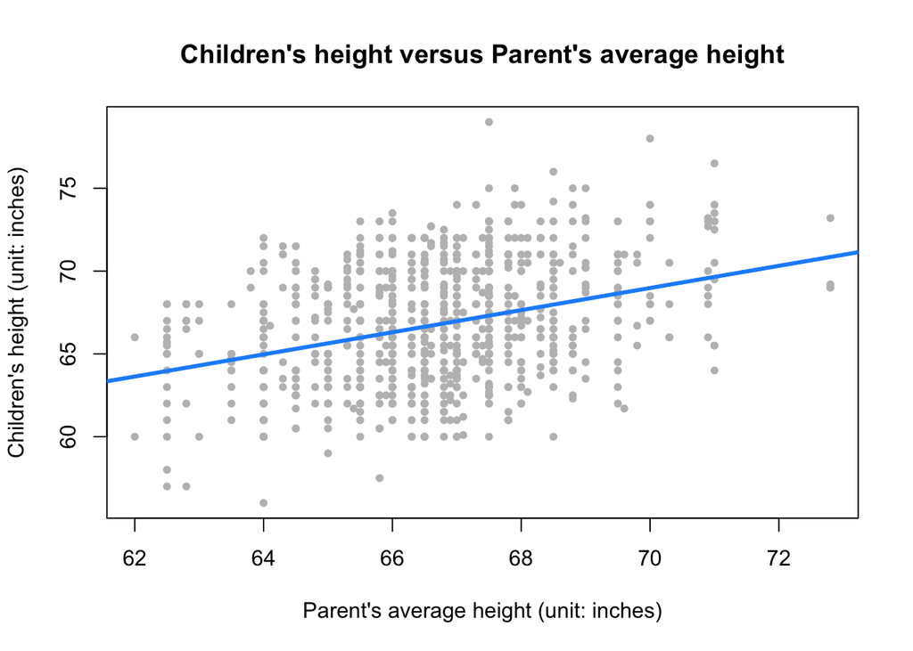

```r
plot(Height ~ Average, data = galton,
     xlab = "Parent's average height (unit: inches)",
     ylab = "Children's height (unit: inches)",
     main = "Children's height versus Parent's average height",
     pch  = 20,
     col  = "grey")
abline(ParentAverageVsKid, lwd = 3, col = "dodgerblue")
```

```r
FatherVsKid = lm(Height ~ Father, data = galton)
summary(FatherVsKid)
```

```
##
## Call:
## lm(formula = Height ~ Father, data = galton)
##
## Residuals:
##      Min       1Q   Median       3Q      Max
## -10.2683  -2.6689  -0.2092   2.6342  11.9329
##
## Coefficients:
##             Estimate Std. Error t value Pr(>|t|)
## (Intercept) 39.11039    3.22706  12.120   <2e-16 ***
## Father       0.39938    0.04658   8.574   <2e-16 ***
## ---
## Signif. codes:  0 '***' 0.001 '**' 0.01 '*' 0.05 '.' 0.1 ' ' 1
##
## Residual standard error: 3.446 on 896 degrees of freedom
## Multiple R-squared:  0.07582,    Adjusted R-squared:  0.07479
## F-statistic: 73.51 on 1 and 896 DF,  p-value: < 2.2e-16
```

```r
anova(FatherVsKid)
```

```
## Analysis of Variance Table
##
## Response: Height
##            Df  Sum Sq Mean Sq F value    Pr(>F)
## Father      1   873.1  873.08  73.508 < 2.2e-16 ***
## Residuals 896 10642.0   11.88
## ---
## Signif. codes:  0 '***' 0.001 '**' 0.01 '*' 0.05 '.' 0.1 ' ' 1
```

```r
FatherVsKidRMSE = sqrt(mean(resid(FatherVsKid)^2))
FatherVsKidRMSE
```

```
## [1] 3.442494
```

We can see that the p-value is nearly equal to zero. So we can have statistical confidence to conclude that there is a linear relationship between father’s height and childen’s height.

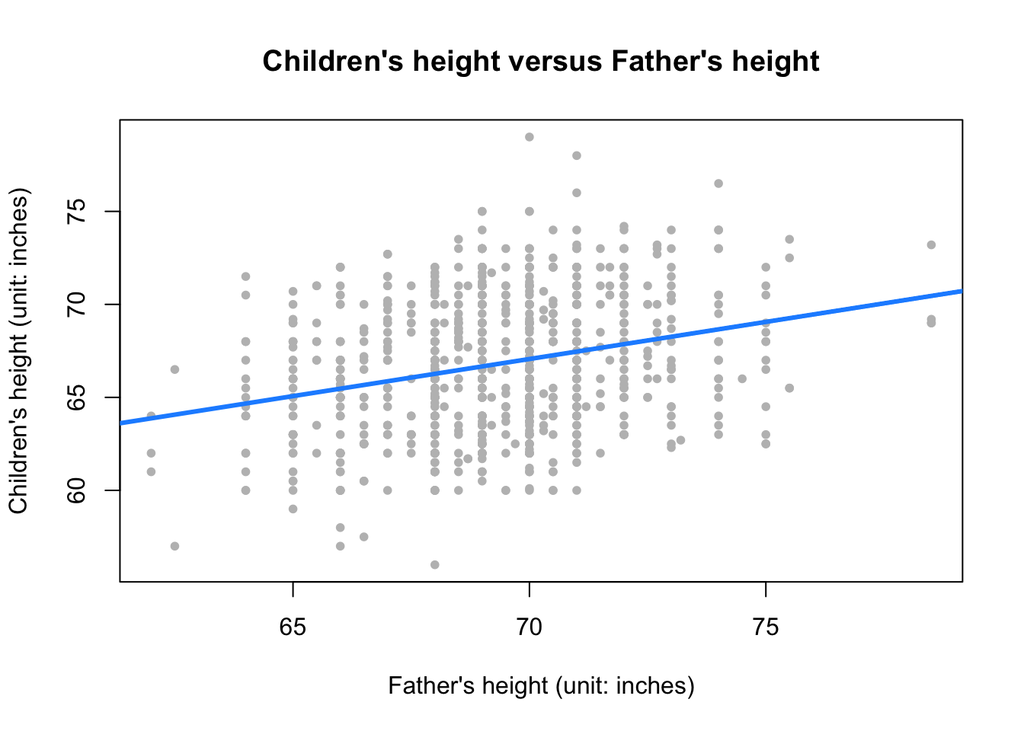

```r
plot(Height ~ Father, data = galton,
     xlab = "Father's height (unit: inches)",
     ylab = "Children's height (unit: inches)",
     main = "Children's height versus Father's height",
     pch  = 20,
     col  = "grey")
abline(FatherVsKid, lwd = 3, col = "dodgerblue")
```

```r
MotherVsKid = lm(Height ~ Mother, data = galton)
summary(MotherVsKid)
```

```
##
## Call:
## lm(formula = Height ~ Mother, data = galton)
##
## Residuals:
##     Min      1Q  Median      3Q     Max
## -9.5474 -2.6346 -0.1079  2.8688 11.9526
##
## Coefficients:
##             Estimate Std. Error t value Pr(>|t|)
## (Intercept) 46.69077    3.25874  14.328  < 2e-16 ***
## Mother       0.31318    0.05082   6.163 1.08e-09 ***
## ---
## Signif. codes:  0 '***' 0.001 '**' 0.01 '*' 0.05 '.' 0.1 ' ' 1
##
## Residual standard error: 3.511 on 896 degrees of freedom
## Multiple R-squared:  0.04066,    Adjusted R-squared:  0.03959
## F-statistic: 37.98 on 1 and 896 DF,  p-value: 1.079e-09
```

```r
anova(MotherVsKid)
```

```
## Analysis of Variance Table
##
## Response: Height
##            Df  Sum Sq Mean Sq F value    Pr(>F)
## Mother      1   468.3  468.26   37.98 1.079e-09 ***
## Residuals 896 11046.8   12.33
## ---
## Signif. codes:  0 '***' 0.001 '**' 0.01 '*' 0.05 '.' 0.1 ' ' 1
```

```r
MotherVsKidRMSE = sqrt(mean(resid(MotherVsKid)^2))
MotherVsKidRMSE
```

```
## [1] 3.507359
```

We can see that the p-value is nearly equal to zero. So we can have statistical confidence to conclude that there is a linear relationship between mother’s height and childen’s height.

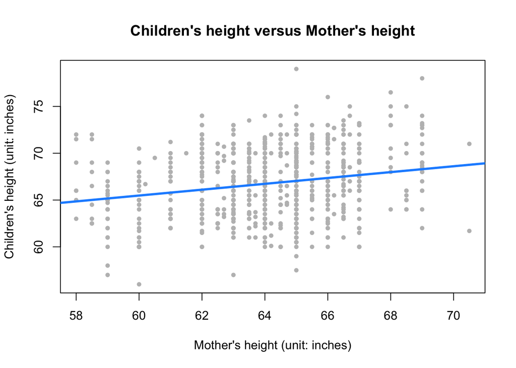

```r
plot(Height ~ Mother, data = galton,
     xlab = "Mother's height (unit: inches)",
     ylab = "Children's height (unit: inches)",
     main = "Children's height versus Mother's height",
     pch  = 20,
     col  = "grey")
abline(MotherVsKid, lwd = 3, col = "dodgerblue")
```

RMSE represents the square root of the average of the error. In these three models, we can see that the first model(Children’s height versus Parent’s average height) has the lowest RMSE, which means it is the most precise one. Then the second(Children’s height versus Father’s height), and the third(Children’s height versus Mother’s height).

So we can conclude that both parents’ height affect the kid’s height, and father’s height is more influential than mother’s height.